# Lecture 13: One time pads

### Announcements

- *Test 2 is this Wednesday at the lecture time and room (10:10am in EPIC 207)*
- Reading Assessment 7 due Fri 10/24 at 6pm, covering [Nakamoto whitepaper](https://bitcoin.org/bitcoin.pdf)
- Lecture participation grades for Units 1-2 have been posted on Gradescope

### Learning outcomes

By the end of today’s lecture, you will learn:

- The power of encryption to protect the confidentiality of data at rest and in transit
- The security objectives of symmetric key encryption
- How to construct a one-time pad, and why it is rarely used in practice today

### Review

**Cryptology** comes from two Greek word parts:

- kryptos, meaning *secret* or *hidden*
- logy, meaning *the study of*

So the goal of cryptology is to study the art of keeping secrets.

More generally, cryptographic systems provide some or all of the objectives in the CIA triad:

- **C**onfidentiality, meaning to keep data or people’s identities hidden from others
- **I**ntegrity, which means preventing raw data or the data science results from being altered, or at least allowing for detection of tampering
- **A**vailability, or ensuring that data science remains accessible and censorship-resistant

So far, we have completed two units of this course.

1. Protecting data **integrity** using digital signatures and message authentication codes
2. Protecting data **availability** with broadcast and blockchains

There are two units remaining in this course.

3. Protecting data **confidentiality** using encryption
4. Protecting data **science**, i.e., working with data you cannot see

## 13.1 Secret splitting

Let me give you an early preview of Unit 4. I will show you how cryptography can protect data science by way of a story – a true story.

In 2013, then-Boston Mayor Tom Menino commissioned a working group to:

- Write a report about how to “make Boston the premier city for working women”
- Establish a new group called the [Boston Women’s Workforce Council](https://thebwwc.org/) to find and implement ways to close the gender and racial wage gap

The Council established a Compact – or pledge – that has been signed by [more than 250 companies](https://thebwwc.org/current-signers) throughout the greater Boston area. The companies promise to do three things; I want to draw your attention to the part about *contributing* data toward measuring the city-wide gender and racial wage gap.

[figure not shown]

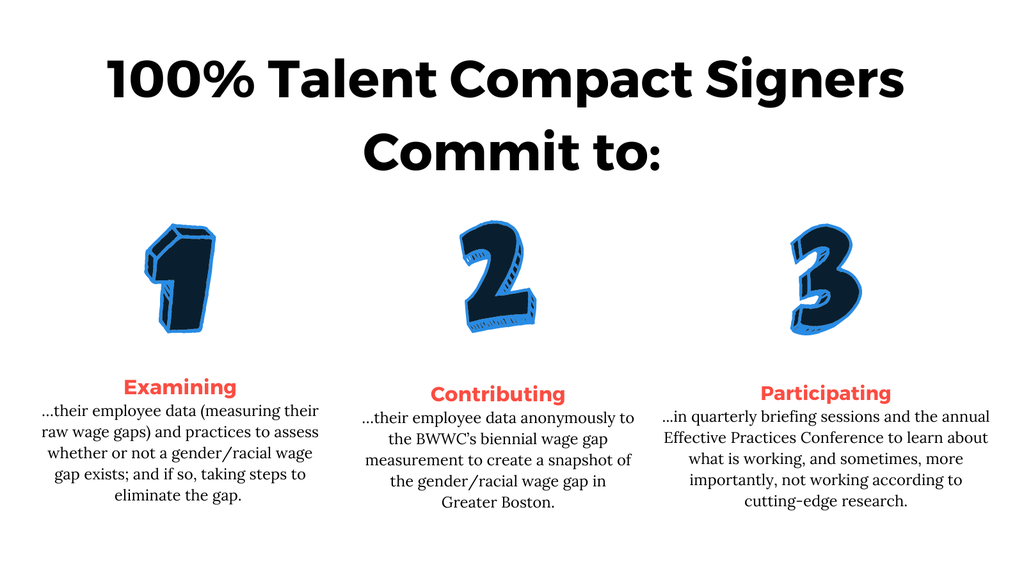

[Image source: [Boston Women’s Workforce Council](https://thebwwc.org/compact-about)]

The text of the pledge reveals the tension between data confidentiality and data analysis.

- *Contributing their employee data anonymously*: everyone wants to keep their own salary data confidential
- *Measurement to create a snapshot of the gender/racial wage gap in Greater Boston*: everyone wants to publish the results of the data analysis

**Question.** How can the companies resolve this tension? How can they perform data analysis while preserving data confidentiality?

The BWWC initially tried to find a trusted intermediary to hold onto the data and compute the city-wide wage gap. However:

1. No company wanted to hand over their salary data to anyone else
2. Nobody wanted to receive salary data from companies across the city

Nevertheless, the Boston Women’s Workforce Council *has* run the data analysis to calculate the city-wide gender and racial wage gap. They have done it 6 times now: in 2016, 2017, 2019, 2021, 2023, and 2025.

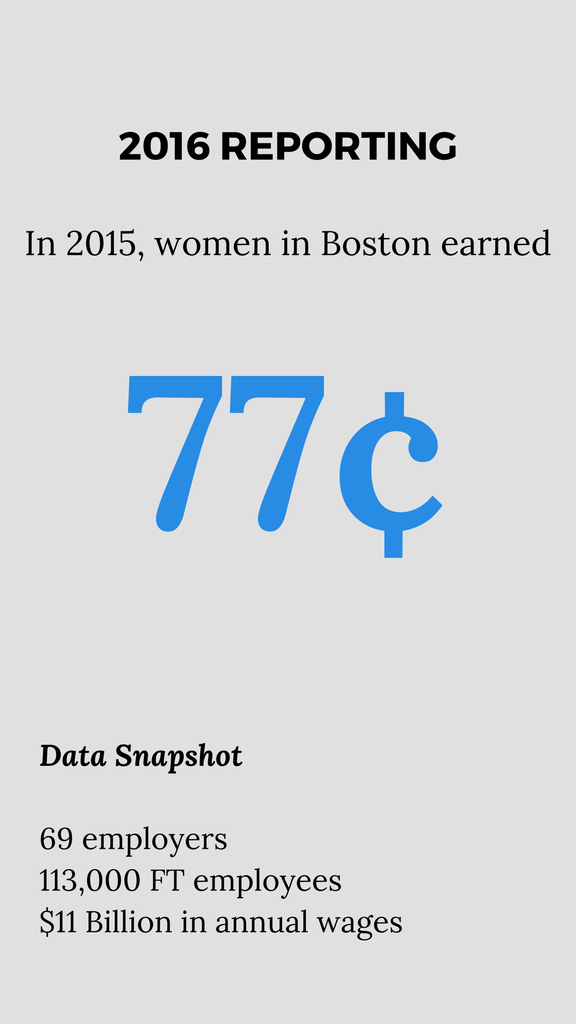

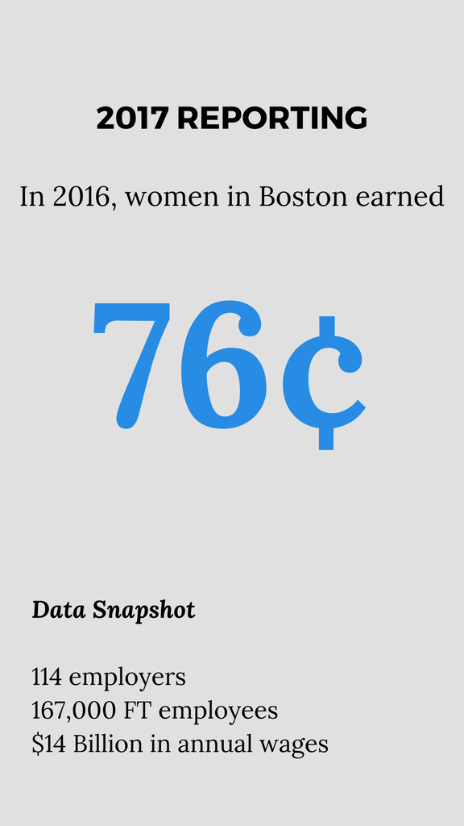

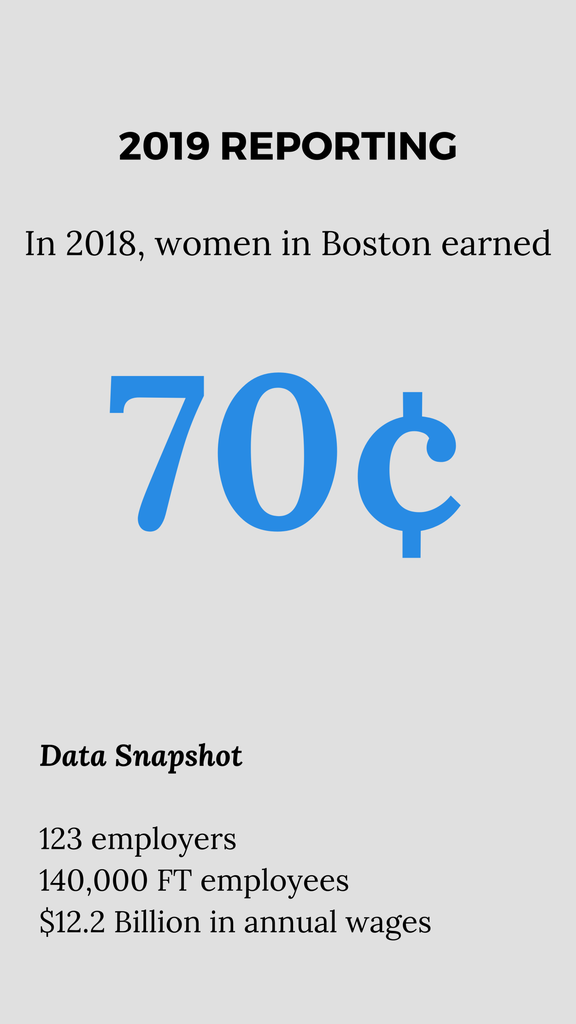

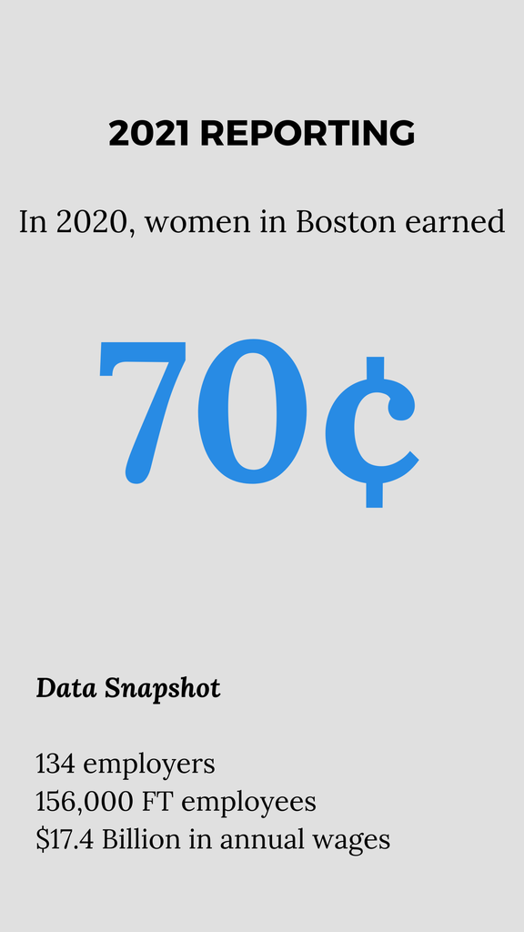

### The website

Several of us at Boston University have worked with the Boston Women’s Workforce Council and the city to design, build, and deploy a web-based survey form. This webpage allows companies to contribute their data toward the wage gap calculation *without* anyone learning their salary data — not even us!

Here’s what our website looks like.

- Someone in (say) the HR department of each participating company inputs the *number* and *total compensation* of all employees in each group of gender, race/ethnicity, and job category
- The spreadsheet follows the format of a U.S. Equal Employment Opportunity Commission form that all large employers must fill out every year

[figure not shown]

100talent.org website in 2017

So far, this looks like an ordinary website. The only special part about it is what happens after you click on the “submit” button.

- With a normal website, clicking “submit” would cause the data to be sent over to the server
- But this website is different. When you click on the “submit” button, the data itself doesn’t go anywhere!

Instead, we use **cryptographic secret splitting** to split the data between BU and the Boston Women’s Workforce Council. We will still be able to calculate the the city-wide total (i.e., the sum across all spreadsheets), but without learning any information about individual employees or employers.

Let’s see how this works using a smaller-scale version of the wage gap project. Suppose that:

- There are only 3 companies that participate in the data analysis
- We only want to calculate one cell within the spreadsheet

### Setup

Let’s call the employers’ individual answers $a$, $b$, and $c$, respectively. Our objective is for:

- The city of Boston to learn only the sum of these numbers $a + b + c$
- Everyone else (including us at BU) to learn nothing

$a$

$b$

$c$

Technically, everyone is interested in the average, not the sum. But since the number of companies is known, it’s straightforward to convert from one to the other: just divide by 3.

### Contributing data

First, each company visits the website and **splits** their secret data between BU and the Council.

- Specifically, the companies send random numbers (e.g., $a_1$ and $a_2$) that have a uniform distribution subject to the fact that they sum to the real secret (e.g., $a = a_1 + a_2 \bmod{2^\ell}$)
- So, neither BU or the Council on their own have learned anything so far, because they each hold a random number

$a$

$b$

$c$

$a_1$

$b_1$

$c_1$

$a_2$

$b_2$

$c_2$

Our overall goal is for the City of Boston to be able to compute $a + b + c$, which is the sum of all six numbers held by BU and BWWC.

Here comes the key insight: because addition is commutative, it doesn’t matter whether we

- first add the numbers vertically and then horizontally, or
- first add the numbers horizontally and then vertically.

And the latter option preserves data confidentiality!

### Aggregating data

Second, BU and the Council add up the three numbers that they possess, and send these results over to the City.

Each of these numbers individually is uniformly random, and it doesn’t reveal anything about $a$, $b$, or $c$ individually, so it preserves the companies’ privacy.

$a$

$b$

$c$

$a_1$

$b_1$

$c_1$

$a_1 + b_1 + c_1$

$a_2$

$b_2$

$c_2$

$a_2 + b_2 + c_2$

Finally, the City of Boston can add the numbers on the right to reconstruct the sum $a + b + c$, whcih is the desired city-wide aggregate statistic.

This is what our web-based software does behind the scenes. It just does it for each of the 100+ participating companies, and for each of the 600+ cells in the spreadsheet.

$a$

$b$

$c$

$a + b + c$

$a_1$

$b_1$

$c_1$

$a_1 + b_1 + c_1$

$a_2$

$b_2$

$c_2$

$a_2 + b_2 + c_2$

**Interactive question.** All of the calculations above are done mod $2^\ell$. What would go wrong if we split $a = a_1 + a_2$ without using modular (or clock) arithmetic?

1. It would be impossible to sample $a_1$ uniformly at random from the integers or real numbers
2. It would take too much network and storage space to send $a_1$ to the BU server
3. Learning $a_1$ would reveal some information about the actual secret $a$
4. All of the above

*Answer*. All of these are reasons why we must use modular arithmetic! Integers or real numbers are unbounded in size, so it is impossible to sample them uniformly at random and they could be significantly bigger than the secret itself.

### Summary

This new way of conducting data science was made possible by cryptographic **secret splitting**, also known as **secret sharing**.

- Secret sharing enables a group of parties to jointly hold a secret, but in such a way that no individual person or small coalition in the group knows the secret.
- Each person holds only a single **share** of the secret – where the word “share” here is used in the sense of a stock share, not in the sense of sharing data.

You can think of secret sharing like a special type of lockbox. Inside the box is a secret message that nobody knows.

- If enough shares are inserted, then the box will open and the secret will be revealed
- Otherwise, the lockbox remains closed and nobody has access to it

[figure not shown]

## 13.2 Encryption

In Unit 3, we will study **encryption** and its role in protecting data **confidentiality**.

> “Cryptography is about communication in the presence of an adversary.”

> – Prof. Ron Rivest

Alice

Mallory

Bob

$\longrightarrow$

[figure not shown]

$\longrightarrow$

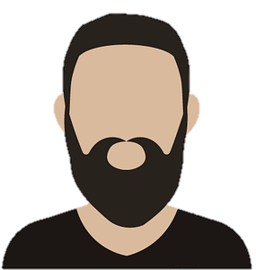

Remember that a digital signature does **not** provide data confidentiality. Instead, its goal is *unforgeability*.

In this example, Alice sends Bob a message with a 64-byte signature. Note that the original message contents remain in the clear.

```python
# using libsodium
from nacl.signing import SigningKey, VerifyKey
from binascii import hexlify

# Alice's key pair
secret_key = SigningKey.generate()
public_key = secret_key.verify_key

# Alice's message and its signature
message = b"Hello, Bob!"
signed_message = secret_key.sign(message)
assert public_key.verify(signed_message), "invalid signature"

print("Length of original message:", len(message), "bytes")
print("Length of signed message:  ", len(signed_message), "bytes\n")
print("Signed message:", hexlify(signed_message[:3]) + b"..." + hexlify(signed_message[-14:-11]) + signed_message[-11:])
```

```
Length of original message: 11 bytes
Length of signed message:   75 bytes

Signed message: b'6707bd...1b6b0dHello, Bob!'
```

Digital signatures allow:

- Alice to “lock” her message using his secret key
- Anyone to “unlock” the message using the corresponding public key

But what if we turn this picture around? What if:

- Anyone can lock a message using the public key
- Only Bob can unlock the message with his secret key

as shown in the left half of the figure?

[figure not shown]

Informal description of encryption and digital signatures (source: [idea-instructions.com](https://idea-instructions.com/public-key/))

The result is a **public key encryption** scheme. This new primitive *does* protect data confidentiality.

```python
from nacl.public import PrivateKey, PublicKey, SealedBox

# Bob's key pair
secret_key = PrivateKey.generate()
public_key = secret_key.public_key # share this with the world
```

```python
# Alice's message and its encryption
message = b"Hello, Bob!"
sealed_box = SealedBox(public_key)
encrypted_message = sealed_box.encrypt(message)

print(encrypted_message)
```

```
b'%k\x89\xd3\x89\xef=\x8d\x92b\xa5\xeb\x03\xbb\x8a\xfd\xe3`\xfcQ\x97\x88\xa4\xec\x83\x90_\xbboeD&\xe6@A\xe2)\xf8z\xac\xb5Z\x9dscV\x96\x84\xd0\x81\xd2#\xc6\x86\xa7$l\xa6\xe9'
```

Also as we will see, encryption schemes are *randomized*: if you encrypt the same message twice, you will get different results. Hence, encryption requires good sources of randomness.

```python
new_encrypted_message = sealed_box.encrypt(message)
print(new_encrypted_message)
```

```
b'\xa9\xd1;\x13z\xc0&\xcd\x13\x8f)nX\xc3\xc3\xc6\xa1\x95\\~/@\xae?\n\xbe\xfbm\x83\x88\x16\x01\x06k\xe9\xda\xd8ehw7\x04=\xbeQ\xfdzE\x80\xea\xda\x96\xa4\x03Ay\x05\x81Y'
```

The goal of Unit 3 of this course is to study encryption and its role in:

- Protecting data at rest on your laptop or phone
- Protecting data in transit over the Internet or messaging app

### The power of encryption

Historically, encryption schemes have been designed and used by governments. It played a significant role in both of the world wars in the 20th century.

[figure not shown]

World War I: Zimmerman telegram (source: [BBC](https://www.bbc.com/news/uk-38581861))

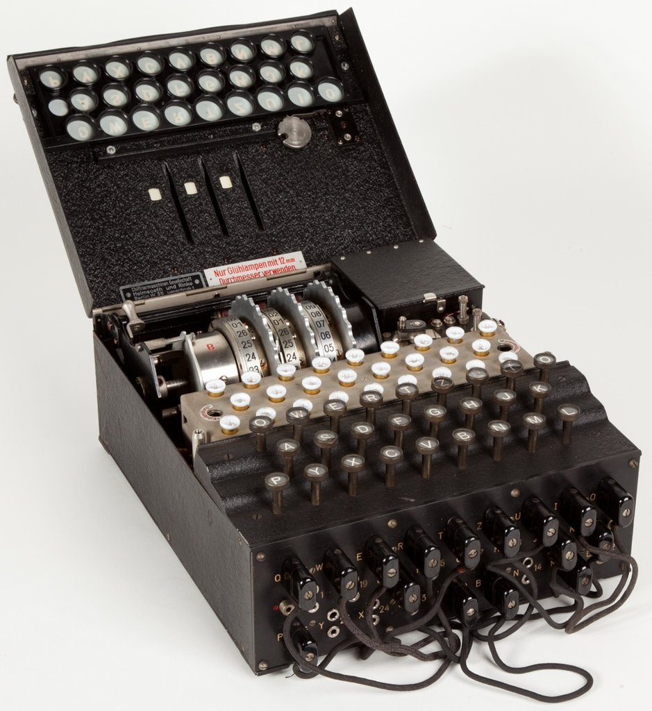

World War II: Enigma machine (source: [Wikipedia](https://en.wikipedia.org/wiki/Enigma_machine))

Modern encryption allows for confidential data exchange over the Internet. Alice can send a chat message, email, file, or database across the internet so that only Bob can read it.

[figure not shown]

Internet communication, with encryption

As a result, encryption is a powerful tool with immense social consequences.

> “Cryptography rearranges power: it configures who can do what, from what.”

> – Prof. Phillip Rogaway (UC Davis)

In particular, having the secret key gives someone the power to decrypt and read a message.

Encryption on the Internet is often performed in one of two ways.

Client-server encryption

End-to-end encryption

Alice encrypts her message with the tech company’s key (and hence, they can read it). Separately, the tech company encrypts a message to Bob.

Alice encrypts her message directly to Bob. While the message passes through the server, the tech company cannot read it.

[figure not shown]

[figure not shown]

You might wonder: *what if* a powerful attacker steals cryptographic keys? This may be possible by (for example) hacking or compelling Alice or Bob to reveal their keys. We will discuss these risks in future lectures. For today, I want to emphasize the value of universal encryption on the Internet.

- With encryption: reading someone’s messages is costly, targeted, and observable
- Without encryption: reading someone’s messages keys is simple, universal, and covert

## 13.3 Symmetric key cryptography

It is possible to construct public key encryption based on hard math problems like factoring and discrete logarithms.

But we will not study public key encryption in this course. In fact, I’m going to make a bold claim: even though it exists, in nearly all data science applications you should **not** use public key encryption! I say this for two reasons.

1. Public key encryption is overkill: it allows anyone on the Internet to send you messages, but in most applications, you know exactly who is going to send you a message
2. Public key encryption is risky: losing control of the secret key for an encryption scheme has immediate, irrecoverable consequences (I will explain this part in more detail in a future lecture)

### One key, rather than two

As a result, we focus in Unit 3 on *symmetric key cryptography*.

- We already know how to build a *message authentication code* for the two parties to send messages to each other with integrity (each party can both tag and verify)
- **Symmetric key encryption** allows two parties to send messages to each other with confidentiality (each party can both encrypt and decrypt)

Looking ahead: these primitives are nearly always used together, and the combined primitive is called **authenticated encryption**.

> “Confidentiality xor authenticity is not possible. If you don’t have both, often you don’t have either.”

> – Prof. Matthew Green (Johns Hopkins)

For today though, let’s focus on encryption by itself.

### Goals and non-goals

Let’s discuss the objectives of symmetric key encryption.

Symmetric key encryption must:

- Hide the contents of Alice and Bob’s messages
- Even if the adversary Mallory has full control over the network and can add, drop, alter, or re-order packets
- Optionally: even if Mallory takes over Alice or Bob’s computer for some time, we might still want to provide confidentiality at other times

However, encryption on its own is not designed to hide “metadata.”

- Encryption doesn’t provide anonymity: Mallory knows that Alice and Bob are communicating
- Encryption doesn’t hide message length: Mallory sees how much data is flowing across the wire

Companies that use encryption sometimes forget about this fact!

**Example 1.** Here is a real interaction between Sen. Ron Wyden and Match, the parent company of Tinder.

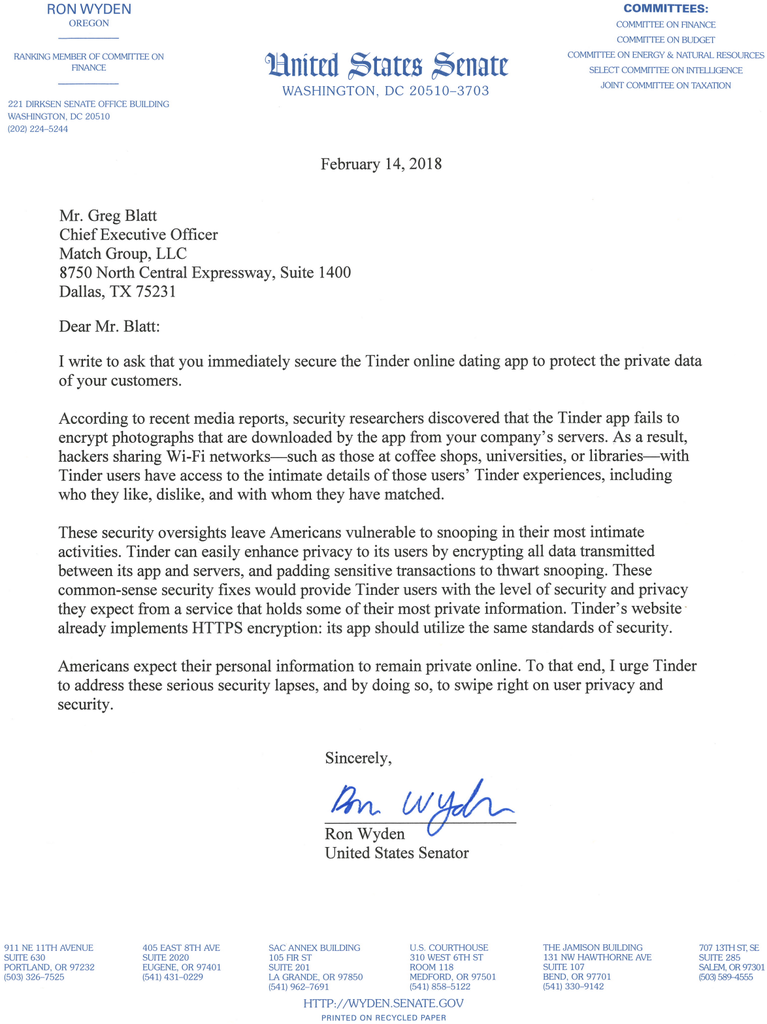

Letter from Sen. Ron Wyden ([link to source](https://www.wyden.senate.gov/imo/media/doc/Letter%20to%20Tinder%20on%20Cybersecurity.pdf))

[figure not shown]

Response from Match Group, Inc. ([link to source](https://www.wyden.senate.gov/imo/media/doc/Match%20response%20to%20wyden%206-27-18%20-%20signed.pdf))

**Example 2.** A company called Voatz tried to build an internet-based voting system for political elections… which is actually a terrible idea for many reasons that we will discuss toward the end of the semester. But they failed at the very first step.

> “The length of the encrypted packet clearly leaks which candidate was selected.”

> – Michael A. Specter, James Koppel, and Daniel Weitzner ([link to paper](https://www.usenix.org/system/files/sec20-specter.pdf))

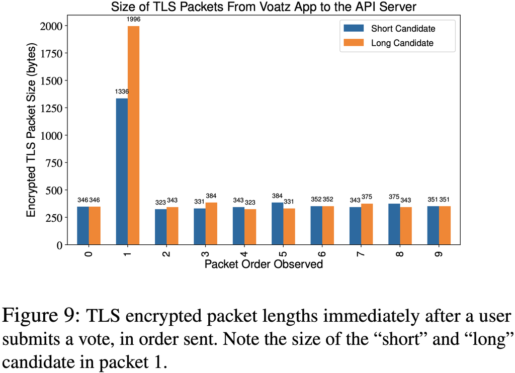

## 13.4 One-time pads

Like signatures, an encryption scheme has three methods: `KeyGen`, `Enc`, and `Dec`.

- `KeyGen`: Alice and Bob jointly sample a symmetric key $k$ from a distribution $\mathcal{K}$ (say, uniformly among bytestrings of a specific length)
- `Enc`$(k, p; r) \to c$: Alice transforms plaintext message $p$ into a ciphertext $c$, with one-time randomness $r$
- `Dec`$(k, c) \to P$: Bob transforms the ciphertext back into the original plaintext message $p$

Encryption satisfies two requirements.

1. **Correctness** (informally): `Dec` undoes the action of `Enc` and allows Bob to read $p$
2. **Secrecy** (informally): If an attacker Mallory sees the ciphertext $c$ but not the symmetric key $k$, then she has no chance of learning *any part* of the plaintext message $p$.

**Question.** How can we make the security requirement precise? In particular:

- What does it mean to learn “part” of the plaintext message $p$?
- How can we take advantage of the randomness $r$ when defining and constructing an encryption scheme?

### Perfect secrecy

Today, we will study one way to formalize the secrecy guarantee.

**Definition 1 (Perfect secrecy)** An encryption scheme satisfies *perfect secrecy* if for any two messages $p_0$ and $p_1$, and for any ciphertext $c$,

$$\Pr[\text{Enc}(k, p_0) = c] = \Pr[\text{Enc}(k, p_1) = c],$$

where this probability is taken over the random choice of the key $k \gets \mathcal{K}$.

Here is one way to think about perfect secrecy.

- If `KeyGen` samples keys uniformly at random, then perfect secrecy says that for any two messages $p_0$ and $p_1$, there are the same number of keys that will map $p_0$ to $c$ and that will map $p_1$ to $c$.
- As a consequence, no amount of computing power is ever enough to recover the real message! Even if Mallory had the energy of the sun, it would not help.
- Even a brute force attack will fail! Or more precisely, it willl find the correct message but also all possible incorrect messages, and will have no way to detect the difference.

### Achieving perfect secrecy

Let’s build an encryption scheme that satisfies perfect secrecy.

- Recall that Mallory can add, drop, alter, or re-order Alice’s messages. This is admittedly a powerful adversary to thwart.
- So for today, we will consider a simpler adversary that only acts as a *passive eavesdropper* but does not change the contents of Alice’s messages. We call this adversary **Eve**.

**Question.** How can Alice encode messages so Eve cannot read them?

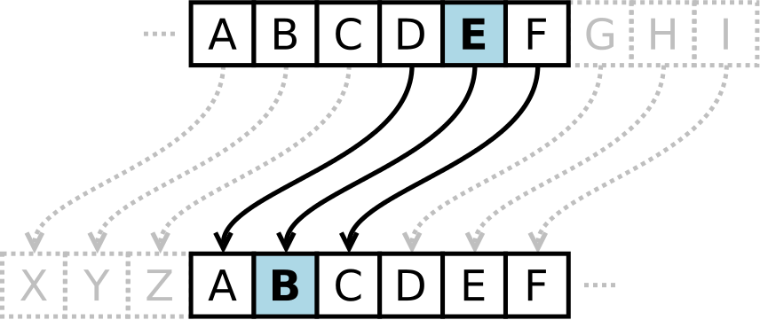

Option 1: substitute each character ([source: Wikipedia](https://en.wikipedia.org/wiki/Caesar_cipher))

[figure not shown]

Option 2: substitute each word or phrase

### Caesar cipher

Let’s try to build a cipher that substitutes one character of the message at a time.

- Our first attempt will be an idea that has been used for thousands of years; in particular, Julius Caesar used it in his private correspondences.
- It will **not** be a secure encryption scheme, but it will provide insights on how to build one.

The idea is to choose a key between 0 and 25, and rotate all characters by this amount. This figure shows the cipher with symmetric key $k = 3$.

- `one` $\mapsto$ `lkb`
- `two` $\mapsto$ `qtl`

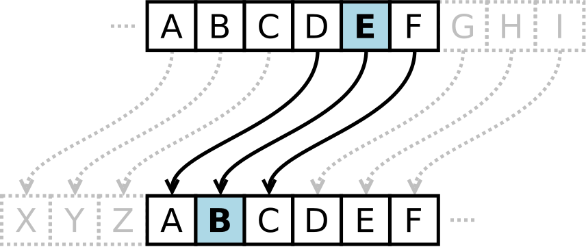

**Question.** Put yourself in the role of Eve. Can you break this encoding?

- If Eve observes the ciphertext $c$ for a known plaintext message $p$, then she learns $k$
- Even if Eve knows a single character of $p$ and $c$, she can encipher a new message: `three` $\mapsto$ `qeobb`

The takeaway message is: reuse of the key leads to a “*frequency attack*.”

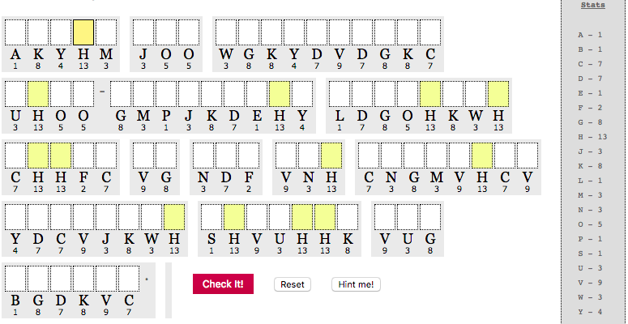

Cryptogram puzzle (image source: [cryptograms.org](https://cryptograms.puzzlebaron.com/))

### Fixing the cipher

Let’s improve the Caesar cipher in two ways:

- To improve security, give each character its own key
- To make the cipher computer-friendly, let’s think about bits instead of characters.

| $\bigoplus$ | 0 | 1 |
| --- | --- | --- |
| 0 | 0 | 1 |
| 1 | 1 | 0 |

The **one-time pad** cipher has a simple construction: the ciphertext is the XOR of the key and the message.

**Question.** Suppose that Alice has the plaintext and key
$$\begin{align*}p &= \text{0110 0110 1001}\\
k &= \text{0011 1100 1110}\end{align*}$$

Using a one-time pad, what is the ciphertext that she should send to Bob?

1. $\text{0010 0100 1000}$
2. $\text{0101 1010 0111}$
3. $\text{0111 1110 1111}$
4. $\text{1010 0101 1000}$

Note that:

- OTP is like secret splitting: we use the `xor` function to split the plaintext message into two pieces, the key and the ciphertext
- OTP “masks” the plaintext message by applying a Caesar cipher independently to each bit
- Since XOR is a lossless function, this encryption scheme is invertible – in fact, XOR is its own inverse

```ruby
      plaintext  0110 0110 1001               cipher     0101 1010 0111
  XOR key        0011 1100 1110           XOR key        0011 1100 1110
      -------------------------               -------------------------
      cipher     0101 1010 0111               plaintext  0110 0110 1001
```

**Theorem 1** The one-time pad satisfies perfect secrecy.

*Proof*. There is a proof of this theorem in [Section 1 of Rosulek’s Joy of Cryptography](https://joyofcryptography.com/pdf/book.pdf), but I encourage you to try to prove this claim on your own before looking there. Remember that perfect secrecy says that for any two plaintext messages $p_0$ and $p_1$ and any ciphertext $c$,

$$\Pr_{k \gets \mathcal{K}}[\text{Enc}(k, p_0) = c] = \Pr_{k \gets \mathcal{K}}[\text{Enc}(k, p_1) = c].$$

### Limitations

Even though it is perfectly secret, the one-time pad is rarely used on its own in practice today for a few reasons:

1. The symmetric key $k$ must be as long as the plaintext message $p$
2. Reusing the same key for two or more messages breaks perfect security, and brings back the cryptograms issue
3. The cipher is malleable! While OTP is safe against a passive eavesdropper Eve, an active attacker Mallory can manipulate the ciphertext in transit and cause the same change in the decrypted plaintext

```ruby
      plaintext  0110 0110 1001               cipher     0101 1010 *1000*
  XOR key        0011 1100 1110           XOR key        0011 1100  1110
      -------------------------               ---------------------------
      cipher     0101 1010 0111               plaintext  0110 0110 *0110*
```

Next week, we will:

- Use pseudorandomness to build ciphers that can encrypt many long messages from a single, short key
- Combine encryption and message authentication codes into a single primitive, so as to protect our data even against an active attacker Mallory